# Face Generation

In this project, you'll use generative adversarial networks to generate new images of faces.

### Get the Data

You'll be using two datasets in this project:

- MNIST
- CelebA

Since the celebA dataset is complex and you're doing GANs in a project for the first time, we want you to test your neural network on MNIST before CelebA. Running the GANs on MNIST will allow you to see how well your model trains sooner.

If you're using [FloydHub](https://www.floydhub.com/), set `data_dir` to "/input" and use the [FloydHub data ID](http://docs.floydhub.com/home/using_datasets/) "R5KrjnANiKVhLWAkpXhNBe".

```python
data_dir = './data'

# FloydHub - Use with data ID "R5KrjnANiKVhLWAkpXhNBe"
#data_dir = '/input'


"""
DON'T MODIFY ANYTHING IN THIS CELL
"""
import helper

helper.download_extract('mnist', data_dir)
helper.download_extract('celeba', data_dir)
```

```
Found mnist Data
Found celeba Data
```

## Explore the Data

### MNIST

As you're aware, the [MNIST](http://yann.lecun.com/exdb/mnist/) dataset contains images of handwritten digits. You can view the first number of examples by changing `show_n_images`.

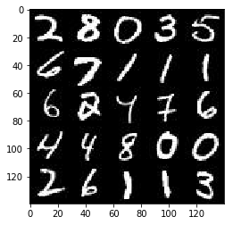

```python
show_n_images = 25

"""
DON'T MODIFY ANYTHING IN THIS CELL
"""
%matplotlib inline
import os
from glob import glob
from matplotlib import pyplot

mnist_images = helper.get_batch(glob(os.path.join(data_dir, 'mnist/*.jpg'))[:show_n_images], 28, 28, 'L')
pyplot.imshow(helper.images_square_grid(mnist_images, 'L'), cmap='gray')
```

### CelebA

The [CelebFaces Attributes Dataset (CelebA)](http://mmlab.ie.cuhk.edu.hk/projects/CelebA.html) dataset contains over 200,000 celebrity images with annotations. Since you're going to be generating faces, you won't need the annotations. You can view the first number of examples by changing `show_n_images`.

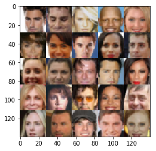

```python
show_n_images = 25

"""
DON'T MODIFY ANYTHING IN THIS CELL
"""
mnist_images = helper.get_batch(glob(os.path.join(data_dir, 'img_align_celeba/*.jpg'))[:show_n_images], 28, 28, 'RGB')
pyplot.imshow(helper.images_square_grid(mnist_images, 'RGB'))
```

## Preprocess the Data

Since the project's main focus is on building the GANs, we'll preprocess the data for you. The values of the MNIST and CelebA dataset will be in the range of -0.5 to 0.5 of 28x28 dimensional images. The CelebA images will be cropped to remove parts of the image that don't include a face, then resized down to 28x28.

The MNIST images are black and white images with a single color channel while the CelebA images have 3 color channels (RGB color channel).

## Build the Neural Network

You'll build the components necessary to build a GANs by implementing the following functions below:

- `model_inputs`
- `discriminator`
- `generator`
- `model_loss`
- `model_opt`
- `train`

### Check the Version of TensorFlow and Access to GPU

This will check to make sure you have the correct version of TensorFlow and access to a GPU

```python
"""
DON'T MODIFY ANYTHING IN THIS CELL
"""
from distutils.version import LooseVersion
import warnings
import tensorflow as tf

# Check TensorFlow Version
assert LooseVersion(tf.__version__) >= LooseVersion('1.0'), 'Please use TensorFlow version 1.0 or newer.  You are using {}'.format(tf.__version__)
print('TensorFlow Version: {}'.format(tf.__version__))

# Check for a GPU
if not tf.test.gpu_device_name():
    warnings.warn('No GPU found. Please use a GPU to train your neural network.')
else:
    print('Default GPU Device: {}'.format(tf.test.gpu_device_name()))
```

```
TensorFlow Version: 1.10.0
Default GPU Device: /device:GPU:0
```

### Input

Implement the `model_inputs` function to create TF Placeholders for the Neural Network. It should create the following placeholders:

- Real input images placeholder with rank 4 using `image_width`, `image_height`, and `image_channels`.
- Z input placeholder with rank 2 using `z_dim`.
- Learning rate placeholder with rank 0.

Return the placeholders in the following the tuple (tensor of real input images, tensor of z data)

```python
import problem_unittests as tests

def model_inputs(image_width, image_height, image_channels, z_dim):
    """
    Create the model inputs
    :param image_width: The input image width
    :param image_height: The input image height
    :param image_channels: The number of image channels
    :param z_dim: The dimension of Z
    :return: Tuple of (tensor of real input images, tensor of z data, learning rate)
    """
    input_real = tf.placeholder(tf.float32, (None, image_width, image_height, image_channels), name='input_real')
    input_z = tf.placeholder(tf.float32, (None, z_dim), name='input_z')
    learning_rate = tf.placeholder(tf.float32, name='learning_rate')

    return input_real, input_z, learning_rate


"""
DON'T MODIFY ANYTHING IN THIS CELL THAT IS BELOW THIS LINE
"""
tests.test_model_inputs(model_inputs)
```

```
Tests Passed
```

### Discriminator

Implement `discriminator` to create a discriminator neural network that discriminates on `images`. This function should be able to reuse the variables in the neural network. Use [`tf.variable_scope`](https://www.tensorflow.org/api_docs/python/tf/variable_scope) with a scope name of "discriminator" to allow the variables to be reused. The function should return a tuple of (tensor output of the discriminator, tensor logits of the discriminator).

```python
def discriminator(images, reuse=False):
    """
    Create the discriminator network
    :param images: Tensor of input image(s)
    :param reuse: Boolean if the weights should be reused
    :return: Tuple of (tensor output of the discriminator, tensor logits of the discriminator)
    """

    with tf.variable_scope("discriminator", reuse=reuse):
        # First layer
        l1 = tf.layers.conv2d(images, 64, 5, strides=2, padding='same')
        leaky1 = tf.maximum(0.2*l1, l1)
        # 14x14x64

        # Second layer
        l2 = tf.layers.conv2d(leaky1, 128, 5, strides=2, padding='same')
        bn2 = tf.layers.batch_normalization(l2, training=True)
        leaky2 = tf.maximum(0.2*bn2, bn2)
        # 7x7x128

        # Third Layer
        l3 = tf.layers.conv2d(leaky2, 256, 5, strides=2, padding='same')
        bn3 = tf.layers.batch_normalization(l3, training=True)
        leaky3 = tf.maximum(0.2 * bn3, bn3)
        # 4x4x256

        # Output
        flat = tf.reshape(leaky3, (-1, 4*4*256))
        logits = tf.layers.dense(flat, 1)
        output = tf.sigmoid(logits)

        return output, logits


"""
DON'T MODIFY ANYTHING IN THIS CELL THAT IS BELOW THIS LINE
"""
tests.test_discriminator(discriminator, tf)
```

```
Tests Passed
```

### Generator

Implement `generator` to generate an image using `z`. This function should be able to reuse the variables in the neural network. Use [`tf.variable_scope`](https://www.tensorflow.org/api_docs/python/tf/variable_scope) with a scope name of "generator" to allow the variables to be reused. The function should return the generated 28 x 28 x `out_channel_dim` images.

```python
def generator(z, out_channel_dim, is_train=True):
    """
    Create the generator network
    :param z: Input z
    :param out_channel_dim: The number of channels in the output image
    :param is_train: Boolean if generator is being used for training
    :return: The tensor output of the generator
    """

    reuse = not is_train
    with tf.variable_scope("generator", reuse=reuse):
        # First Layer
        l1 = tf.layers.dense(z, 3*3*512)
        r1 = tf.reshape(l1, (-1, 3, 3, 512))
        bn1 = tf.layers.batch_normalization(r1, training=is_train)
        leaky1 = tf.maximum(0.2*bn1, bn1)
        # 3x3x512

        # Second Layer
        l2 = tf.layers.conv2d_transpose(leaky1, 256, 5, strides=2, padding='same')
        bn2 = tf.layers.batch_normalization(l2, training=is_train)
        leaky2 = tf.maximum(0.2*bn2, bn2)
        # 6x6x256

        # Third Layer
        l3 = tf.layers.conv2d_transpose(leaky2, 128, 4, strides=2, padding='valid')
        bn3 = tf.layers.batch_normalization(l3, training=is_train)
        leaky3 = tf.maximum(0.2 * bn3, bn3)
        #14x14x128

        # Output
        logits = tf.layers.conv2d_transpose(leaky3, out_channel_dim, 5, strides=2, padding='same')
        # 8x8x out_channel_dim

        return tf.tanh(logits)


"""
DON'T MODIFY ANYTHING IN THIS CELL THAT IS BELOW THIS LINE
"""
tests.test_generator(generator, tf)
```

```
Tests Passed
```

### Loss

Implement `model_loss` to build the GANs for training and calculate the loss. The function should return a tuple of (discriminator loss, generator loss). Use the following functions you implemented:

- `discriminator(images, reuse=False)`
- `generator(z, out_channel_dim, is_train=True)`

```python
def model_loss(input_real, input_z, out_channel_dim):
    """
    Get the loss for the discriminator and generator
    :param input_real: Images from the real dataset
    :param input_z: Z input
    :param out_channel_dim: The number of channels in the output image
    :return: A tuple of (discriminator loss, generator loss)
    """

    g_model = generator(input_z, out_channel_dim)
    d_model_real, d_logits_real = discriminator(input_real)
    d_model_fake, d_logits_fake = discriminator(g_model, reuse=True)

    d_loss_real = tf.reduce_mean(tf.nn.sigmoid_cross_entropy_with_logits(logits=d_logits_real,
                                                                         labels=tf.ones_like(d_model_real)))
    d_loss_fake = tf.reduce_mean(tf.nn.sigmoid_cross_entropy_with_logits(logits=d_logits_fake,
                                                                         labels=tf.zeros_like(d_model_fake)))
    g_loss = tf.reduce_mean(tf.nn.sigmoid_cross_entropy_with_logits(logits=d_logits_fake,
                                                                    labels=tf.ones_like(d_model_fake)))

    d_loss = d_loss_real + d_loss_fake

    return d_loss, g_loss


"""
DON'T MODIFY ANYTHING IN THIS CELL THAT IS BELOW THIS LINE
"""
tests.test_model_loss(model_loss)
```

```
Tests Passed
```

### Optimization

Implement `model_opt` to create the optimization operations for the GANs. Use [`tf.trainable_variables`](https://www.tensorflow.org/api_docs/python/tf/trainable_variables) to get all the trainable variables. Filter the variables with names that are in the discriminator and generator scope names. The function should return a tuple of (discriminator training operation, generator training operation).

```python
def model_opt(d_loss, g_loss, learning_rate, beta1):
    """
    Get optimization operations
    :param d_loss: Discriminator loss Tensor
    :param g_loss: Generator loss Tensor
    :param learning_rate: Learning Rate Placeholder
    :param beta1: The exponential decay rate for the 1st moment in the optimizer
    :return: A tuple of (discriminator training operation, generator training operation)
    """
    t_vars = tf.trainable_variables()
    d_vars = [var for var in t_vars if var.name.startswith('discriminator')]
    g_vars = [var for var in t_vars if var.name.startswith('generator')]

    with tf.control_dependencies(tf.get_collection(tf.GraphKeys.UPDATE_OPS)):
        d_train_opt = tf.train.AdamOptimizer(learning_rate, beta1=beta1).minimize(d_loss, var_list=d_vars)
        g_train_opt = tf.train.AdamOptimizer(learning_rate, beta1=beta1).minimize(g_loss, var_list=g_vars)

    return d_train_opt, g_train_opt


"""
DON'T MODIFY ANYTHING IN THIS CELL THAT IS BELOW THIS LINE
"""
tests.test_model_opt(model_opt, tf)
```

```
Tests Passed
```

## Neural Network Training

### Show Output

Use this function to show the current output of the generator during training. It will help you determine how well the GANs is training.

```python
"""
DON'T MODIFY ANYTHING IN THIS CELL
"""
import numpy as np

def show_generator_output(sess, n_images, input_z, out_channel_dim, image_mode):
    """
    Show example output for the generator
    :param sess: TensorFlow session
    :param n_images: Number of Images to display
    :param input_z: Input Z Tensor
    :param out_channel_dim: The number of channels in the output image
    :param image_mode: The mode to use for images ("RGB" or "L")
    """
    cmap = None if image_mode == 'RGB' else 'gray'
    z_dim = input_z.get_shape().as_list()[-1]
    example_z = np.random.uniform(-1, 1, size=[n_images, z_dim])

    samples = sess.run(
        generator(input_z, out_channel_dim, False),
        feed_dict={input_z: example_z})

    images_grid = helper.images_square_grid(samples, image_mode)
    pyplot.imshow(images_grid, cmap=cmap)
    pyplot.show()
```

### Train

Implement `train` to build and train the GANs. Use the following functions you implemented:

- `model_inputs(image_width, image_height, image_channels, z_dim)`
- `model_loss(input_real, input_z, out_channel_dim)`
- `model_opt(d_loss, g_loss, learning_rate, beta1)`

Use the `show_generator_output` to show `generator` output while you train. Running `show_generator_output` for every batch will drastically increase training time and increase the size of the notebook. It's recommended to print the `generator` output every 100 batches.

```python
def train(epoch_count, batch_size, z_dim, learning_rate, beta1, get_batches, data_shape, data_image_mode):
    """
    Train the GAN
    :param epoch_count: Number of epochs
    :param batch_size: Batch Size
    :param z_dim: Z dimension
    :param learning_rate: Learning Rate
    :param beta1: The exponential decay rate for the 1st moment in the optimizer
    :param get_batches: Function to get batches
    :param data_shape: Shape of the data
    :param data_image_mode: The image mode to use for images ("RGB" or "L")
    """
    print_step = 10
    show_step = 100
    dropout = 0.75
    images_to_show = 9
    losses =[]
    step = 0

    _, width, height, channels = data_shape

    r_input, z_input, lr = model_inputs(width, height, channels, z_dim)

    d_loss, g_loss = model_loss(r_input, z_input, channels)
    d_opt, g_opt = model_opt(d_loss, g_loss, lr, beta1)

    print("Started")
    with tf.Session() as sess:
        sess.run(tf.global_variables_initializer())
        for epoch_i in range(epoch_count):
            for batch_images in get_batches(batch_size):
                step += 1
                batch_images = 2*batch_images

                # Random Noise
                z_batch = np.random.uniform(-1, 1, size=(batch_size, z_dim))

                _ = sess.run(d_opt, feed_dict={r_input: batch_images, z_input: z_batch, lr: learning_rate})
                _ = sess.run(g_opt, feed_dict={z_input: z_batch, r_input: batch_images, lr: learning_rate})

                if step % print_step == 0:
                    train_loss_d = d_loss.eval({z_input: z_batch, r_input: batch_images})
                    train_loss_g = g_loss.eval({z_input: z_batch})

                    print("Step: {}:".format(step),
                          "Epoch {}/{}...".format(epoch_i+1, epoch_count),
                          "Discriminator Loss: {:.4f}...".format(train_loss_d),
                          "Generator Loss: {:.4f}".format(train_loss_g))
                    losses.append((train_loss_d, train_loss_g))

                if step % show_step == 0:
                    show_generator_output(sess, images_to_show, z_input, channels, data_image_mode)
    print("Finished")
```

### MNIST

Test your GANs architecture on MNIST. After 2 epochs, the GANs should be able to generate images that look like handwritten digits. Make sure the loss of the generator is lower than the loss of the discriminator or close to 0.

```
Started
Step: 10: Epoch 1/2... Discriminator Loss: 0.7291... Generator Loss: 4.5462
Step: 20: Epoch 1/2... Discriminator Loss: 1.7983... Generator Loss: 1.1867
Step: 30: Epoch 1/2... Discriminator Loss: 1.4362... Generator Loss: 3.5317
Step: 40: Epoch 1/2... Discriminator Loss: 0.9978... Generator Loss: 0.6603
Step: 50: Epoch 1/2... Discriminator Loss: 1.0249... Generator Loss: 0.5708
Step: 60: Epoch 1/2... Discriminator Loss: 0.5551... Generator Loss: 3.9888
Step: 70: Epoch 1/2... Discriminator Loss: 0.8219... Generator Loss: 0.7284
Step: 80: Epoch 1/2... Discriminator Loss: 1.2494... Generator Loss: 4.2660
Step: 90: Epoch 1/2... Discriminator Loss: 1.6064... Generator Loss: 0.4481
Step: 100: Epoch 1/2... Discriminator Loss: 1.9140... Generator Loss: 0.3003
```

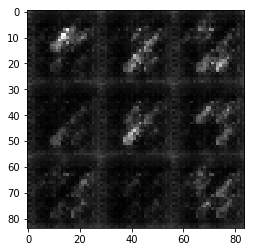

```
Step: 110: Epoch 1/2... Discriminator Loss: 1.2271... Generator Loss: 0.6254
Step: 120: Epoch 1/2... Discriminator Loss: 1.2384... Generator Loss: 0.6627
Step: 130: Epoch 1/2... Discriminator Loss: 0.8219... Generator Loss: 1.2769
Step: 140: Epoch 1/2... Discriminator Loss: 0.6339... Generator Loss: 1.1393
Step: 150: Epoch 1/2... Discriminator Loss: 0.5420... Generator Loss: 1.6119
Step: 160: Epoch 1/2... Discriminator Loss: 0.7814... Generator Loss: 4.0665
Step: 170: Epoch 1/2... Discriminator Loss: 0.5791... Generator Loss: 1.5993
Step: 180: Epoch 1/2... Discriminator Loss: 1.5308... Generator Loss: 0.4305
Step: 190: Epoch 1/2... Discriminator Loss: 0.9632... Generator Loss: 0.7618
Step: 200: Epoch 1/2... Discriminator Loss: 1.1811... Generator Loss: 0.6155
```

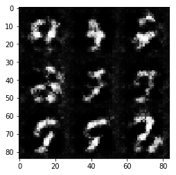

```
Step: 210: Epoch 1/2... Discriminator Loss: 0.9559... Generator Loss: 2.5567
Step: 220: Epoch 1/2... Discriminator Loss: 0.9483... Generator Loss: 1.6657
Step: 230: Epoch 1/2... Discriminator Loss: 0.9121... Generator Loss: 1.0910
Step: 240: Epoch 1/2... Discriminator Loss: 1.2768... Generator Loss: 2.2776
Step: 250: Epoch 1/2... Discriminator Loss: 0.9077... Generator Loss: 0.8490
Step: 260: Epoch 1/2... Discriminator Loss: 0.8429... Generator Loss: 1.3287
Step: 270: Epoch 1/2... Discriminator Loss: 1.1161... Generator Loss: 0.6353
Step: 280: Epoch 1/2... Discriminator Loss: 1.4513... Generator Loss: 0.3057
Step: 290: Epoch 1/2... Discriminator Loss: 1.2739... Generator Loss: 0.4370
Step: 300: Epoch 1/2... Discriminator Loss: 0.9662... Generator Loss: 0.8573
```

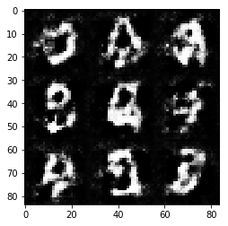

```
Step: 310: Epoch 1/2... Discriminator Loss: 1.0309... Generator Loss: 1.4748
Step: 320: Epoch 1/2... Discriminator Loss: 0.9041... Generator Loss: 1.1471
Step: 330: Epoch 1/2... Discriminator Loss: 1.6016... Generator Loss: 0.2896
Step: 340: Epoch 1/2... Discriminator Loss: 1.0181... Generator Loss: 0.9503
Step: 350: Epoch 1/2... Discriminator Loss: 0.9547... Generator Loss: 0.7168
Step: 360: Epoch 1/2... Discriminator Loss: 1.1968... Generator Loss: 1.4628
Step: 370: Epoch 1/2... Discriminator Loss: 0.7681... Generator Loss: 1.7361
Step: 380: Epoch 1/2... Discriminator Loss: 0.9301... Generator Loss: 1.6524
Step: 390: Epoch 1/2... Discriminator Loss: 0.9824... Generator Loss: 0.8337
Step: 400: Epoch 1/2... Discriminator Loss: 0.7763... Generator Loss: 1.2573
```

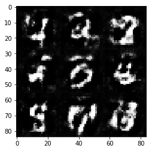

```
Step: 410: Epoch 1/2... Discriminator Loss: 1.5943... Generator Loss: 0.3348
Step: 420: Epoch 1/2... Discriminator Loss: 0.7730... Generator Loss: 1.7546
Step: 430: Epoch 1/2... Discriminator Loss: 0.8947... Generator Loss: 0.9058
Step: 440: Epoch 1/2... Discriminator Loss: 0.8494... Generator Loss: 1.2297
Step: 450: Epoch 1/2... Discriminator Loss: 0.9640... Generator Loss: 0.8731
Step: 460: Epoch 1/2... Discriminator Loss: 0.9358... Generator Loss: 1.3886
Step: 470: Epoch 1/2... Discriminator Loss: 1.0782... Generator Loss: 0.5422
Step: 480: Epoch 1/2... Discriminator Loss: 0.8186... Generator Loss: 1.0604
Step: 490: Epoch 1/2... Discriminator Loss: 1.1565... Generator Loss: 2.5091
Step: 500: Epoch 1/2... Discriminator Loss: 1.0367... Generator Loss: 1.1252
```

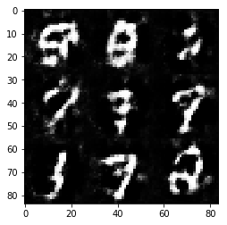

```
Step: 510: Epoch 1/2... Discriminator Loss: 1.0807... Generator Loss: 1.8537
Step: 520: Epoch 1/2... Discriminator Loss: 0.7221... Generator Loss: 1.2698
Step: 530: Epoch 1/2... Discriminator Loss: 0.9436... Generator Loss: 1.8475
Step: 540: Epoch 1/2... Discriminator Loss: 1.6345... Generator Loss: 0.2643
Step: 550: Epoch 1/2... Discriminator Loss: 1.0171... Generator Loss: 1.2360
Step: 560: Epoch 1/2... Discriminator Loss: 0.7715... Generator Loss: 1.4143
Step: 570: Epoch 1/2... Discriminator Loss: 0.9063... Generator Loss: 1.1605
Step: 580: Epoch 1/2... Discriminator Loss: 0.9250... Generator Loss: 1.9075
Step: 590: Epoch 1/2... Discriminator Loss: 1.6242... Generator Loss: 0.2685
Step: 600: Epoch 1/2... Discriminator Loss: 0.9193... Generator Loss: 1.0440
```

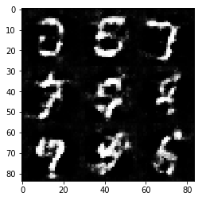

```
Step: 610: Epoch 1/2... Discriminator Loss: 1.7522... Generator Loss: 0.2608
Step: 620: Epoch 1/2... Discriminator Loss: 1.2159... Generator Loss: 0.4726
Step: 630: Epoch 1/2... Discriminator Loss: 1.6210... Generator Loss: 0.3272
Step: 640: Epoch 1/2... Discriminator Loss: 1.0063... Generator Loss: 0.8191
Step: 650: Epoch 1/2... Discriminator Loss: 1.0901... Generator Loss: 0.5802
Step: 660: Epoch 1/2... Discriminator Loss: 1.1617... Generator Loss: 1.7550
Step: 670: Epoch 1/2... Discriminator Loss: 1.8522... Generator Loss: 2.6549
Step: 680: Epoch 1/2... Discriminator Loss: 1.4455... Generator Loss: 0.3493
Step: 690: Epoch 1/2... Discriminator Loss: 1.3592... Generator Loss: 0.3941
Step: 700: Epoch 1/2... Discriminator Loss: 1.2482... Generator Loss: 0.4759
```

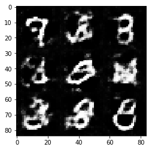

```
Step: 710: Epoch 1/2... Discriminator Loss: 1.2901... Generator Loss: 0.4227
Step: 720: Epoch 1/2... Discriminator Loss: 1.0484... Generator Loss: 0.6192
Step: 730: Epoch 1/2... Discriminator Loss: 0.9859... Generator Loss: 0.6042
Step: 740: Epoch 1/2... Discriminator Loss: 1.0889... Generator Loss: 0.6669
Step: 750: Epoch 1/2... Discriminator Loss: 1.1765... Generator Loss: 2.4952
Step: 760: Epoch 1/2... Discriminator Loss: 1.1023... Generator Loss: 0.5714
Step: 770: Epoch 1/2... Discriminator Loss: 1.5829... Generator Loss: 0.2846
Step: 780: Epoch 1/2... Discriminator Loss: 1.1812... Generator Loss: 0.5559
Step: 790: Epoch 1/2... Discriminator Loss: 1.2630... Generator Loss: 0.4887
Step: 800: Epoch 1/2... Discriminator Loss: 1.3289... Generator Loss: 0.3714
```

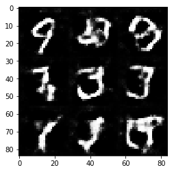

```
Step: 810: Epoch 1/2... Discriminator Loss: 0.7473... Generator Loss: 1.2093
Step: 820: Epoch 1/2... Discriminator Loss: 0.7799... Generator Loss: 0.9561
Step: 830: Epoch 1/2... Discriminator Loss: 1.3267... Generator Loss: 0.3932
Step: 840: Epoch 1/2... Discriminator Loss: 1.0619... Generator Loss: 0.6734
Step: 850: Epoch 1/2... Discriminator Loss: 0.9530... Generator Loss: 0.7940
Step: 860: Epoch 1/2... Discriminator Loss: 1.1898... Generator Loss: 0.4959
Step: 870: Epoch 1/2... Discriminator Loss: 0.9521... Generator Loss: 0.7001
Step: 880: Epoch 1/2... Discriminator Loss: 2.0009... Generator Loss: 0.2333
Step: 890: Epoch 1/2... Discriminator Loss: 0.8317... Generator Loss: 1.1374
Step: 900: Epoch 1/2... Discriminator Loss: 1.1535... Generator Loss: 0.5499
```

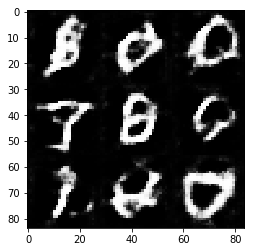

```
Step: 910: Epoch 1/2... Discriminator Loss: 1.0057... Generator Loss: 0.7661
Step: 920: Epoch 1/2... Discriminator Loss: 1.2309... Generator Loss: 0.4879
Step: 930: Epoch 1/2... Discriminator Loss: 1.1512... Generator Loss: 1.2658
Step: 940: Epoch 1/2... Discriminator Loss: 1.0240... Generator Loss: 0.6436
Step: 950: Epoch 1/2... Discriminator Loss: 1.0334... Generator Loss: 0.6638
Step: 960: Epoch 1/2... Discriminator Loss: 1.5753... Generator Loss: 0.3100
Step: 970: Epoch 1/2... Discriminator Loss: 0.9230... Generator Loss: 0.9618
Step: 980: Epoch 1/2... Discriminator Loss: 0.8664... Generator Loss: 0.9299
Step: 990: Epoch 1/2... Discriminator Loss: 0.9053... Generator Loss: 0.8201
Step: 1000: Epoch 1/2... Discriminator Loss: 0.9549... Generator Loss: 0.7604
```

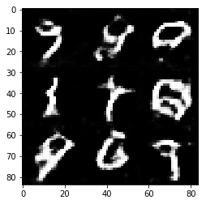

```
Step: 1010: Epoch 1/2... Discriminator Loss: 1.1278... Generator Loss: 0.5859
Step: 1020: Epoch 1/2... Discriminator Loss: 1.4227... Generator Loss: 2.0551
Step: 1030: Epoch 1/2... Discriminator Loss: 0.8513... Generator Loss: 1.5890
Step: 1040: Epoch 1/2... Discriminator Loss: 0.9161... Generator Loss: 0.7307
Step: 1050: Epoch 1/2... Discriminator Loss: 0.9989... Generator Loss: 0.6077
Step: 1060: Epoch 1/2... Discriminator Loss: 0.7104... Generator Loss: 1.2277
Step: 1070: Epoch 1/2... Discriminator Loss: 1.3790... Generator Loss: 0.4130
Step: 1080: Epoch 1/2... Discriminator Loss: 0.8142... Generator Loss: 1.6818
Step: 1090: Epoch 1/2... Discriminator Loss: 1.1072... Generator Loss: 0.5453
Step: 1100: Epoch 1/2... Discriminator Loss: 0.8960... Generator Loss: 0.6844
```

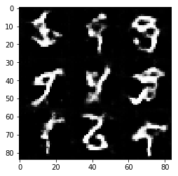

```
Step: 1110: Epoch 1/2... Discriminator Loss: 1.4541... Generator Loss: 0.3564
Step: 1120: Epoch 1/2... Discriminator Loss: 1.1640... Generator Loss: 0.5124
Step: 1130: Epoch 1/2... Discriminator Loss: 1.5007... Generator Loss: 0.3312
Step: 1140: Epoch 1/2... Discriminator Loss: 0.9786... Generator Loss: 0.7601
Step: 1150: Epoch 1/2... Discriminator Loss: 1.4406... Generator Loss: 0.3448
Step: 1160: Epoch 1/2... Discriminator Loss: 0.8071... Generator Loss: 1.1457
Step: 1170: Epoch 1/2... Discriminator Loss: 2.0447... Generator Loss: 0.1779
Step: 1180: Epoch 1/2... Discriminator Loss: 1.1262... Generator Loss: 0.5320
Step: 1190: Epoch 1/2... Discriminator Loss: 1.0400... Generator Loss: 0.6582
Step: 1200: Epoch 1/2... Discriminator Loss: 0.8916... Generator Loss: 0.6895
```

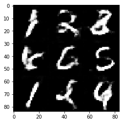

```
Step: 1210: Epoch 1/2... Discriminator Loss: 0.9540... Generator Loss: 0.7248
Step: 1220: Epoch 1/2... Discriminator Loss: 0.6839... Generator Loss: 1.3731
Step: 1230: Epoch 1/2... Discriminator Loss: 0.9953... Generator Loss: 0.6250
Step: 1240: Epoch 1/2... Discriminator Loss: 1.3282... Generator Loss: 0.4237
Step: 1250: Epoch 1/2... Discriminator Loss: 1.2403... Generator Loss: 0.4701
Step: 1260: Epoch 1/2... Discriminator Loss: 0.8932... Generator Loss: 0.8707
Step: 1270: Epoch 1/2... Discriminator Loss: 0.6183... Generator Loss: 1.4864
Step: 1280: Epoch 1/2... Discriminator Loss: 2.6344... Generator Loss: 0.1226
Step: 1290: Epoch 1/2... Discriminator Loss: 1.2134... Generator Loss: 0.4698
Step: 1300: Epoch 1/2... Discriminator Loss: 0.5710... Generator Loss: 1.7064
```

[25 more figures not shown]

```
Step: 3710: Epoch 2/2... Discriminator Loss: 0.5176... Generator Loss: 1.3087
Step: 3720: Epoch 2/2... Discriminator Loss: 0.6625... Generator Loss: 0.9742
Step: 3730: Epoch 2/2... Discriminator Loss: 0.8828... Generator Loss: 0.7153
Step: 3740: Epoch 2/2... Discriminator Loss: 0.4906... Generator Loss: 1.3583
Step: 3750: Epoch 2/2... Discriminator Loss: 1.2880... Generator Loss: 0.5065
Finished
```

```python
batch_size = 32
z_dim = 200
learning_rate = 0.0002
beta1 = 0.3


"""
DON'T MODIFY ANYTHING IN THIS CELL THAT IS BELOW THIS LINE
"""
epochs = 2

mnist_dataset = helper.Dataset('mnist', glob(os.path.join(data_dir, 'mnist/*.jpg')))
with tf.Graph().as_default():
    train(epochs, batch_size, z_dim, learning_rate, beta1, mnist_dataset.get_batches,
          mnist_dataset.shape, mnist_dataset.image_mode)
```

### CelebA

Run your GANs on CelebA. It will take around 20 minutes on the average GPU to run one epoch. You can run the whole epoch or stop when it starts to generate realistic faces.

```
Started
Step: 10: Epoch 1/1... Discriminator Loss: 0.6195... Generator Loss: 1.3370
Step: 20: Epoch 1/1... Discriminator Loss: 3.5102... Generator Loss: 0.0367
Step: 30: Epoch 1/1... Discriminator Loss: 2.4144... Generator Loss: 0.1183
Step: 40: Epoch 1/1... Discriminator Loss: 0.4839... Generator Loss: 5.2550
Step: 50: Epoch 1/1... Discriminator Loss: 0.2432... Generator Loss: 2.3671
Step: 60: Epoch 1/1... Discriminator Loss: 0.2589... Generator Loss: 3.2441
Step: 70: Epoch 1/1... Discriminator Loss: 1.1974... Generator Loss: 8.9779
Step: 80: Epoch 1/1... Discriminator Loss: 0.4920... Generator Loss: 2.3364
Step: 90: Epoch 1/1... Discriminator Loss: 0.6925... Generator Loss: 1.0474
Step: 100: Epoch 1/1... Discriminator Loss: 0.8079... Generator Loss: 2.8828
```

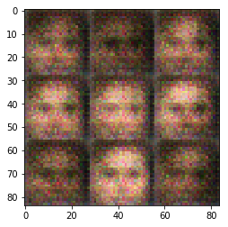

```
Step: 110: Epoch 1/1... Discriminator Loss: 1.1097... Generator Loss: 0.5477
Step: 120: Epoch 1/1... Discriminator Loss: 0.7177... Generator Loss: 0.9631
Step: 130: Epoch 1/1... Discriminator Loss: 1.5703... Generator Loss: 0.3559
Step: 140: Epoch 1/1... Discriminator Loss: 1.1738... Generator Loss: 5.0271
Step: 150: Epoch 1/1... Discriminator Loss: 0.9690... Generator Loss: 1.6497
Step: 160: Epoch 1/1... Discriminator Loss: 1.1688... Generator Loss: 0.6794
Step: 170: Epoch 1/1... Discriminator Loss: 1.2575... Generator Loss: 0.4450
Step: 180: Epoch 1/1... Discriminator Loss: 0.8986... Generator Loss: 1.1249
Step: 190: Epoch 1/1... Discriminator Loss: 1.1916... Generator Loss: 1.2390
Step: 200: Epoch 1/1... Discriminator Loss: 1.3191... Generator Loss: 0.6519
```

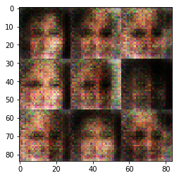

```
Step: 210: Epoch 1/1... Discriminator Loss: 1.0050... Generator Loss: 1.0104
Step: 220: Epoch 1/1... Discriminator Loss: 1.7471... Generator Loss: 0.2950
Step: 230: Epoch 1/1... Discriminator Loss: 1.2867... Generator Loss: 0.5124
Step: 240: Epoch 1/1... Discriminator Loss: 1.9836... Generator Loss: 0.2154
Step: 250: Epoch 1/1... Discriminator Loss: 1.4100... Generator Loss: 3.0318
Step: 260: Epoch 1/1... Discriminator Loss: 1.1377... Generator Loss: 2.9412
Step: 270: Epoch 1/1... Discriminator Loss: 1.2329... Generator Loss: 0.6413
Step: 280: Epoch 1/1... Discriminator Loss: 0.6826... Generator Loss: 1.8425
Step: 290: Epoch 1/1... Discriminator Loss: 0.7375... Generator Loss: 1.7585
Step: 300: Epoch 1/1... Discriminator Loss: 1.5683... Generator Loss: 0.3377
```

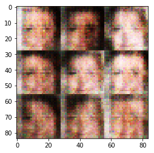

```
Step: 310: Epoch 1/1... Discriminator Loss: 1.0565... Generator Loss: 0.5817
Step: 320: Epoch 1/1... Discriminator Loss: 1.3493... Generator Loss: 0.4949
Step: 330: Epoch 1/1... Discriminator Loss: 1.4358... Generator Loss: 0.4530
Step: 340: Epoch 1/1... Discriminator Loss: 0.8774... Generator Loss: 1.9873
Step: 350: Epoch 1/1... Discriminator Loss: 1.3145... Generator Loss: 0.4192
Step: 360: Epoch 1/1... Discriminator Loss: 1.0268... Generator Loss: 0.7251
Step: 370: Epoch 1/1... Discriminator Loss: 0.8078... Generator Loss: 0.9155
Step: 380: Epoch 1/1... Discriminator Loss: 1.9216... Generator Loss: 0.2363
Step: 390: Epoch 1/1... Discriminator Loss: 0.8937... Generator Loss: 0.9110
Step: 400: Epoch 1/1... Discriminator Loss: 0.7543... Generator Loss: 1.0192
```

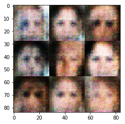

```
Step: 410: Epoch 1/1... Discriminator Loss: 0.9895... Generator Loss: 2.5218
Step: 420: Epoch 1/1... Discriminator Loss: 1.4409... Generator Loss: 0.3829
Step: 430: Epoch 1/1... Discriminator Loss: 0.4914... Generator Loss: 2.3971
Step: 440: Epoch 1/1... Discriminator Loss: 0.8370... Generator Loss: 1.8632
Step: 450: Epoch 1/1... Discriminator Loss: 1.0448... Generator Loss: 0.7292
Step: 460: Epoch 1/1... Discriminator Loss: 0.5259... Generator Loss: 1.4643
Step: 470: Epoch 1/1... Discriminator Loss: 0.7174... Generator Loss: 1.7254
Step: 480: Epoch 1/1... Discriminator Loss: 1.3438... Generator Loss: 0.5190
Step: 490: Epoch 1/1... Discriminator Loss: 0.7360... Generator Loss: 1.5098
Step: 500: Epoch 1/1... Discriminator Loss: 2.0390... Generator Loss: 0.2048
```

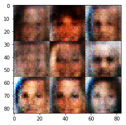

```
Step: 510: Epoch 1/1... Discriminator Loss: 1.5320... Generator Loss: 0.3705
Step: 520: Epoch 1/1... Discriminator Loss: 2.5345... Generator Loss: 0.1407
Step: 530: Epoch 1/1... Discriminator Loss: 1.2836... Generator Loss: 0.4720
Step: 540: Epoch 1/1... Discriminator Loss: 0.6689... Generator Loss: 1.5627
Step: 550: Epoch 1/1... Discriminator Loss: 0.7438... Generator Loss: 1.3890
Step: 560: Epoch 1/1... Discriminator Loss: 2.2767... Generator Loss: 0.1455
Step: 570: Epoch 1/1... Discriminator Loss: 0.9024... Generator Loss: 1.0576
Step: 580: Epoch 1/1... Discriminator Loss: 1.5448... Generator Loss: 2.8506
Step: 590: Epoch 1/1... Discriminator Loss: 0.8713... Generator Loss: 2.6945
Step: 600: Epoch 1/1... Discriminator Loss: 1.1295... Generator Loss: 0.6481
```

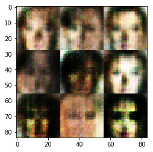

```
Step: 610: Epoch 1/1... Discriminator Loss: 0.9954... Generator Loss: 0.6536
Step: 620: Epoch 1/1... Discriminator Loss: 1.3944... Generator Loss: 0.4528
Step: 630: Epoch 1/1... Discriminator Loss: 0.7791... Generator Loss: 1.2290
Step: 640: Epoch 1/1... Discriminator Loss: 1.3537... Generator Loss: 0.4392
Step: 650: Epoch 1/1... Discriminator Loss: 0.7670... Generator Loss: 1.6991
Step: 660: Epoch 1/1... Discriminator Loss: 0.7661... Generator Loss: 2.1077
Step: 670: Epoch 1/1... Discriminator Loss: 0.7733... Generator Loss: 0.9472
Step: 680: Epoch 1/1... Discriminator Loss: 2.2854... Generator Loss: 0.1338
Step: 690: Epoch 1/1... Discriminator Loss: 1.6994... Generator Loss: 0.3009
Step: 700: Epoch 1/1... Discriminator Loss: 1.1209... Generator Loss: 0.6729
```

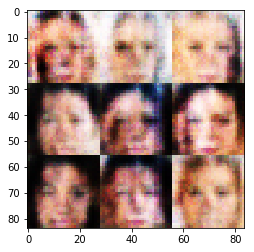

```
Step: 710: Epoch 1/1... Discriminator Loss: 0.6970... Generator Loss: 1.9876
Step: 720: Epoch 1/1... Discriminator Loss: 0.8510... Generator Loss: 1.5702
Step: 730: Epoch 1/1... Discriminator Loss: 0.6398... Generator Loss: 2.5254
Step: 740: Epoch 1/1... Discriminator Loss: 0.6806... Generator Loss: 1.2195
Step: 750: Epoch 1/1... Discriminator Loss: 1.4800... Generator Loss: 0.4002
Step: 760: Epoch 1/1... Discriminator Loss: 0.7208... Generator Loss: 1.1522
Step: 770: Epoch 1/1... Discriminator Loss: 1.4381... Generator Loss: 0.3905
Step: 780: Epoch 1/1... Discriminator Loss: 0.5233... Generator Loss: 1.9195
Step: 790: Epoch 1/1... Discriminator Loss: 1.1960... Generator Loss: 3.4555
Step: 800: Epoch 1/1... Discriminator Loss: 0.5270... Generator Loss: 3.1203
```

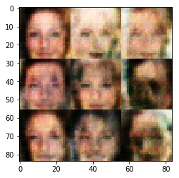

```
Step: 810: Epoch 1/1... Discriminator Loss: 0.5564... Generator Loss: 2.1833
Step: 820: Epoch 1/1... Discriminator Loss: 0.7872... Generator Loss: 1.3426
Step: 830: Epoch 1/1... Discriminator Loss: 1.8056... Generator Loss: 0.2349
Step: 840: Epoch 1/1... Discriminator Loss: 1.8475... Generator Loss: 0.2020
Step: 850: Epoch 1/1... Discriminator Loss: 0.6791... Generator Loss: 1.2687
Step: 860: Epoch 1/1... Discriminator Loss: 1.2924... Generator Loss: 2.2553
Step: 870: Epoch 1/1... Discriminator Loss: 0.6277... Generator Loss: 1.6911
Step: 880: Epoch 1/1... Discriminator Loss: 1.8252... Generator Loss: 0.2329
Step: 890: Epoch 1/1... Discriminator Loss: 1.2979... Generator Loss: 0.4700
Step: 900: Epoch 1/1... Discriminator Loss: 1.6184... Generator Loss: 0.2994
```

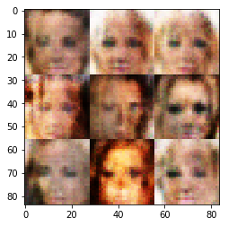

```
Step: 910: Epoch 1/1... Discriminator Loss: 0.7068... Generator Loss: 1.7097
Step: 920: Epoch 1/1... Discriminator Loss: 1.1579... Generator Loss: 1.4962
Step: 930: Epoch 1/1... Discriminator Loss: 0.6390... Generator Loss: 1.8638
Step: 940: Epoch 1/1... Discriminator Loss: 1.1277... Generator Loss: 2.2957
Step: 950: Epoch 1/1... Discriminator Loss: 0.8631... Generator Loss: 1.0254
Step: 960: Epoch 1/1... Discriminator Loss: 1.0275... Generator Loss: 1.7317
Step: 970: Epoch 1/1... Discriminator Loss: 1.2774... Generator Loss: 0.4414
Step: 980: Epoch 1/1... Discriminator Loss: 0.7709... Generator Loss: 1.0843
Step: 990: Epoch 1/1... Discriminator Loss: 1.3719... Generator Loss: 0.4142
Step: 1000: Epoch 1/1... Discriminator Loss: 1.4700... Generator Loss: 0.4016
```

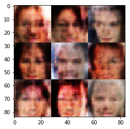

```
Step: 1010: Epoch 1/1... Discriminator Loss: 1.0555... Generator Loss: 0.6233
Step: 1020: Epoch 1/1... Discriminator Loss: 1.2581... Generator Loss: 0.4611
Step: 1030: Epoch 1/1... Discriminator Loss: 0.8971... Generator Loss: 1.0419
Step: 1040: Epoch 1/1... Discriminator Loss: 1.2426... Generator Loss: 0.4894
Step: 1050: Epoch 1/1... Discriminator Loss: 1.0937... Generator Loss: 0.6248
Step: 1060: Epoch 1/1... Discriminator Loss: 0.7280... Generator Loss: 1.5709
Step: 1070: Epoch 1/1... Discriminator Loss: 1.2193... Generator Loss: 2.2848
Step: 1080: Epoch 1/1... Discriminator Loss: 1.4082... Generator Loss: 0.3987
Step: 1090: Epoch 1/1... Discriminator Loss: 1.2072... Generator Loss: 1.2147
Step: 1100: Epoch 1/1... Discriminator Loss: 1.7898... Generator Loss: 0.2462
```

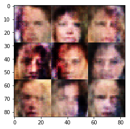

```
Step: 1110: Epoch 1/1... Discriminator Loss: 1.0740... Generator Loss: 1.6778
Step: 1120: Epoch 1/1... Discriminator Loss: 1.3313... Generator Loss: 0.4205
Step: 1130: Epoch 1/1... Discriminator Loss: 0.8917... Generator Loss: 1.4997
Step: 1140: Epoch 1/1... Discriminator Loss: 0.9160... Generator Loss: 0.8438
Step: 1150: Epoch 1/1... Discriminator Loss: 0.8369... Generator Loss: 1.0789
Step: 1160: Epoch 1/1... Discriminator Loss: 0.9459... Generator Loss: 0.8901
Step: 1170: Epoch 1/1... Discriminator Loss: 1.2056... Generator Loss: 0.5702
Step: 1180: Epoch 1/1... Discriminator Loss: 1.1155... Generator Loss: 1.1699
Step: 1190: Epoch 1/1... Discriminator Loss: 1.1583... Generator Loss: 0.5311
Step: 1200: Epoch 1/1... Discriminator Loss: 1.1112... Generator Loss: 1.4790
```

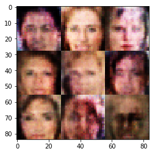

```
Step: 1210: Epoch 1/1... Discriminator Loss: 1.0806... Generator Loss: 0.8469
Step: 1220: Epoch 1/1... Discriminator Loss: 1.5134... Generator Loss: 0.3283
Step: 1230: Epoch 1/1... Discriminator Loss: 1.0332... Generator Loss: 1.3133
Step: 1240: Epoch 1/1... Discriminator Loss: 1.1650... Generator Loss: 1.6522
Step: 1250: Epoch 1/1... Discriminator Loss: 1.3478... Generator Loss: 0.4745
Step: 1260: Epoch 1/1... Discriminator Loss: 1.0557... Generator Loss: 0.6620
Step: 1270: Epoch 1/1... Discriminator Loss: 0.9150... Generator Loss: 2.1714
Step: 1280: Epoch 1/1... Discriminator Loss: 1.0114... Generator Loss: 0.6505
Step: 1290: Epoch 1/1... Discriminator Loss: 0.9282... Generator Loss: 0.7834
Step: 1300: Epoch 1/1... Discriminator Loss: 0.7115... Generator Loss: 1.0000
```

[51 more figures not shown]

```
Step: 6310: Epoch 1/1... Discriminator Loss: 1.1379... Generator Loss: 0.5733
Step: 6320: Epoch 1/1... Discriminator Loss: 0.9798... Generator Loss: 0.7951
Step: 6330: Epoch 1/1... Discriminator Loss: 0.6539... Generator Loss: 0.9978
Finished
```

```python
batch_size = 32
z_dim = 200
learning_rate = 0.0002
beta1 = 0.3


"""
DON'T MODIFY ANYTHING IN THIS CELL THAT IS BELOW THIS LINE
"""
epochs = 1

celeba_dataset = helper.Dataset('celeba', glob(os.path.join(data_dir, 'img_align_celeba/*.jpg')))
with tf.Graph().as_default():
    train(epochs, batch_size, z_dim, learning_rate, beta1, celeba_dataset.get_batches,
          celeba_dataset.shape, celeba_dataset.image_mode)
```

### Submitting This Project

When submitting this project, make sure to run all the cells before saving the notebook. Save the notebook file as "dlnd_face_generation.ipynb" and save it as a HTML file under "File" -> "Download as". Include the "helper.py" and "problem_unittests.py" files in your submission.